### k-means cluster analysis of scotch whiskies

```
library(RCurl)
library(XML)
library(corrplot)
library(NbClust)
library(tidyr)
library(ggplot2)
library(ggmap)

RCurl & XML：擷取 URL 網頁資料及解析 XML / HTML.
corrplot：相關矩陣可視化.
NbClust：決定最佳群集數.
tidyr：資料整理工具.
ggplot2 & ggmap：繪圖及空間可視化.
```

學習是一條漫長的過程， [How to get good at R](http://www.kdnuggets.com/2016/11/data-science-101-good-at-r.html) 給了2點建議： 挑選感興趣的主題、建立學習 blog，我想 Learning by doing 的確很重要，但要落實真的需要決心，雖然不容易但總得跨出第一步。想起先前在網路上看到的 whisky 資料集…於是，這個主題便誕生了，希望能成為學習的助燃劑，順便幫忙回顧整理一下這些日子所見所學。使用的資料集來自 https://www.mathstat.strath.ac.uk/outreach/nessie/nessie_whisky.html

原始資料共86筆，17個變數欄位，包括流水編號(RowID)、蒸餾廠名稱(Distillery)、威士忌風味(3至14欄:Body, Sweetness, Smoky, Medicinal, Tobacco, Honey, Spicy, Winey, Nutty, Malty, Fruity, Floral)、郵遞區號(Postcode)、緯度(Latitude)及經度(Longitude)。不過由於原始資料中 Latitude 與 Longitude 為圖檔座標值並非經緯度，於是利用 Postcode 欄位及 RCurl, XML 套件，配合 http://postal-code.org/postalcode/GB/ 提供的服務，取得網頁資料進行 xpath 解析。

```r
# use Postcode to get Latitude, Longitude
url <- paste0("http://postal-code.org/postalcode/GB/", p)
html <- htmlParse(getURL(url))
postal <- xpathSApply(html, "//div[@class='Postal_Code_HTML_Block_Text']", xmlValue)
```

以上多數 Distillery 的經緯度可透過郵遞區號來得到，剩下約10來筆對應不到的 ，考量原始資料不多(只有86筆)的情形下，不宜直接刪除，輔以人工進行處理。透過 https://en.wikipedia.org/wiki/List_of_whisky_distilleries_in_Scotland 可查到相關 Distillery 的經緯度…待補齊剩下的資料，確認 identical 資料順序無誤後，整併成 whisky.all 資料框架，匯出儲存方便後續使用。whisky.all 資料結構及前5筆資料顯示如下…

```
## 'data.frame':    86 obs. of  17 variables:
##  $ RowID     : int  1 2 3 4 5 6 7 8 9 10 ...
##  $ Distillery: chr  "Aberfeldy" "Aberlour" "AnCnoc" "Ardbeg" ...
##  $ Body      : int  2 3 1 4 2 2 0 2 2 2 ...
##  $ Sweetness : int  2 3 3 1 2 3 2 3 2 3 ...
##  $ Smoky     : int  2 1 2 4 2 1 0 1 1 2 ...
##  $ Medicinal : int  0 0 0 4 0 1 0 0 0 1 ...
##  $ Tobacco   : int  0 0 0 0 0 0 0 0 0 0 ...
##  $ Honey     : int  2 4 2 0 1 1 1 2 1 0 ...
##  $ Spicy     : int  1 3 0 2 1 1 1 1 0 2 ...
##  $ Winey     : int  2 2 0 0 1 1 0 2 0 0 ...
##  $ Nutty     : int  2 2 2 1 2 0 2 2 2 2 ...
##  $ Malty     : int  2 3 2 2 3 1 2 2 2 1 ...
##  $ Fruity    : int  2 3 3 1 1 1 3 2 2 2 ...
##  $ Floral    : int  2 2 2 0 1 2 3 1 2 1 ...
##  $ Postcode  : chr  "PH152EB" "AB389PJ" "AB55LI" "PA427EB" ...
##  $ Latitude  : num  56.6 57.5 57.6 55.6 57.4 ...
##  $ Longitude : num  -3.85 -3.23 -2.76 -6.11 -2.74 ...
```

```
##   RowID Distillery Body Sweetness Smoky Medicinal Tobacco Honey Spicy
## 1     1  Aberfeldy    2         2     2         0       0     2     1
## 2     2   Aberlour    3         3     1         0       0     4     3
## 3     3     AnCnoc    1         3     2         0       0     2     0
## 4     4     Ardbeg    4         1     4         4       0     0     2
## 5     5    Ardmore    2         2     2         0       0     1     1
##   Winey Nutty Malty Fruity Floral Postcode Latitude Longitude
## 1     2     2     2      2      2  PH152EB 56.62507 -3.850515
## 2     2     2     3      3      2  AB389PJ 57.46726 -3.229973
## 3     0     2     2      3      2   AB55LI 57.56333 -2.759167
## 4     0     1     2      1      0  PA427EB 55.64018 -6.109065
## 5     1     2     3      1      1  AB544NH 57.35042 -2.743877
```

威士忌風味(3至14欄)相關矩陣探討，使用的是 corrplot 套件，我覺得這套件的可視化比 ellipse 套件來的易懂。下圖藍色代表正相關、紅色為負相關，方塊大小表示其相關程度，圖中顯示 Smoky 與 Medicinal 正相關程度最高，Smoky 與 Body 也很高。而 Floral 與 Medicinal, Body, Smoky 則明顯的負相關，Sweetness 與 Smoky, Medicinal 負相關程度也是很高，Honey 與 Medicinal 也是。這個結果與我對 whisky 的基本認知似乎滿一致的，顯示資料集具有一定的參考性…

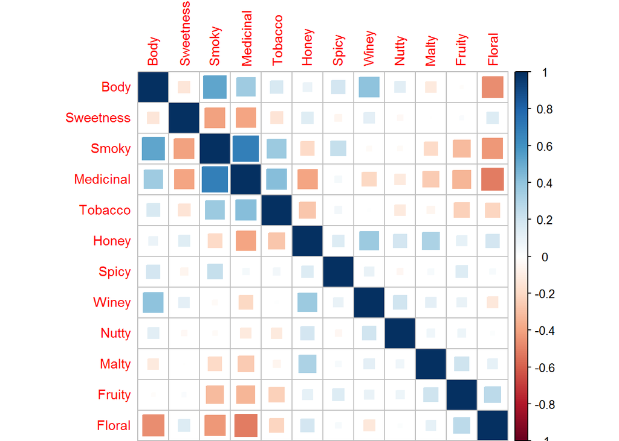

```r
# correlation
whisky.cor <- cor(whisky.all[,3:14])
whisky.cor <- round(whisky.cor, digits=3)
# plot
corrplot(whisky.cor, method='square', tl.cex = 0.9)
```

接著，探討86筆資料中威士忌風味(3至14欄)的群集關係，使用的是 k-means 分群法，由於尚未知道適宜的群數(k)，因此預先設定2至15群分別執行，為避免一次性的偏差、確保較理想的分群結果，每次程序重複執行20次，記錄每次分群的 Sum Of Squares 結果於 k.performance。之後利用 ggplot2 套件，繪成 Sum Of Squares By Cluster 圖表，由下圖可發現，當資料分成2群和3群時(k = 2 和 k = 3)，Sum Of Squares 明顯下降最多，k = 3 和 k =4 的降幅也相較於其他多一些，因此，初步判定適宜的群數(k)可定為3或4

```r
# k.performance
k.performance <- data.frame()
set.seed(777)
for (k in 2:15) {
  k.clusters <- kmeans(whisky.all[, 3:14], k, nstart = 20)
  sum.squares <- sum(k.clusters$withinss)
  k.performance <-
    rbind(k.performance,
          data.frame(
            K = k,
            SumSquares = sum.squares,
            stringsAsFactors = F
          ))
}
```

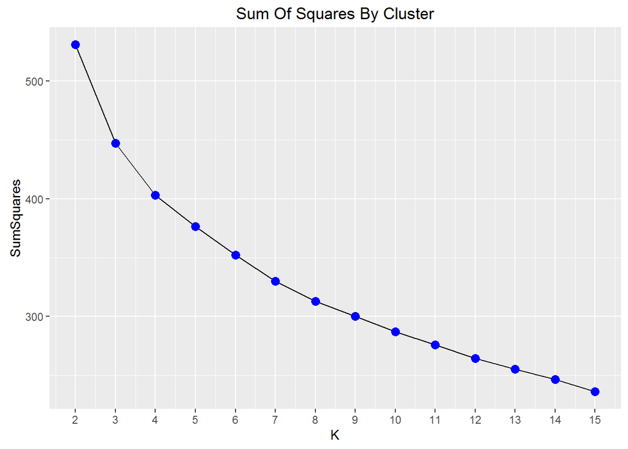

除了人工的判定，最佳群數的決定也可以利用 NbClust 套件來輔助，透過執行圖表發現 k 由2至3時，相關指數值上升/下降最多，執行的結果當 k =3 時最佳。最終，86筆資料分成3群，群集1有50筆資料、群集2有25筆、群集3有11筆，每群的群心值如下表，透過 ggplot2 套件繪成 Whisky Flavor Mean Score By Groups 圖表，從圖中可發現群集1屬於酒體(Body)偏低、柔和的花果香調性，群集2則酒體偏強、具有明顯麥芽、堅果、蜂蜜、葡萄…等味道，群集3屬於較不香甜但有強烈酒體、濃濃煙燻藥水等特性…(腦海直覺 it’s Islay)

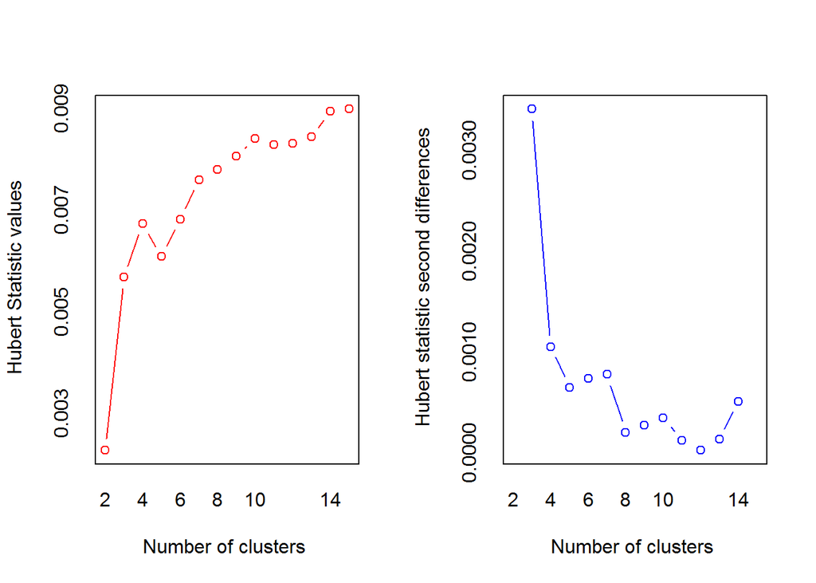

```
## *** : The Hubert index is a graphical method of determining the number of clusters.
##                 In the plot of Hubert index, we seek a significant knee that corresponds to a
##                 significant increase of the value of the measure i.e the significant peak in Hubert
##                 index second differences plot.
##
```

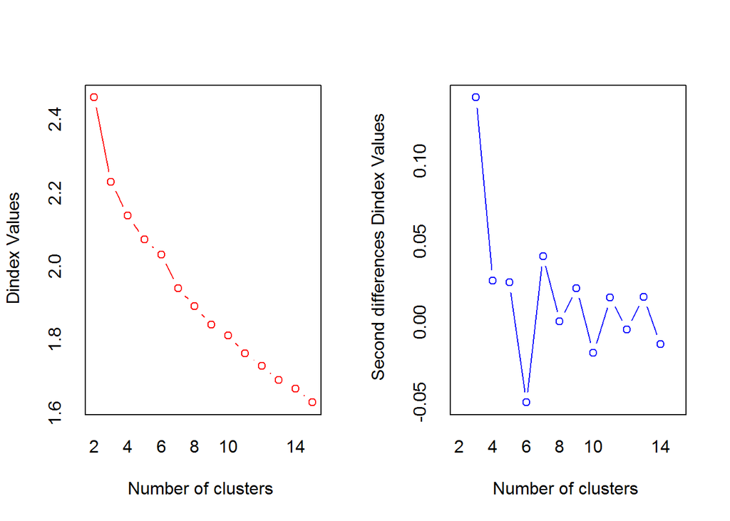

```
## *** : The D index is a graphical method of determining the number of clusters.
##                 In the plot of D index, we seek a significant knee (the significant peak in Dindex
##                 second differences plot) that corresponds to a significant increase of the value of
##                 the measure.
##
## * Among all indices:
## * 3 proposed 2 as the best number of clusters
## * 12 proposed 3 as the best number of clusters
## * 3 proposed 4 as the best number of clusters
## * 1 proposed 9 as the best number of clusters
## * 1 proposed 11 as the best number of clusters
## * 3 proposed 15 as the best number of clusters
##
##                    ***** Conclusion *****
##
## * According to the majority rule, the best number of clusters is  3
##
##
```

```
## Groups
##  1  2  3
## 50 25 11
```

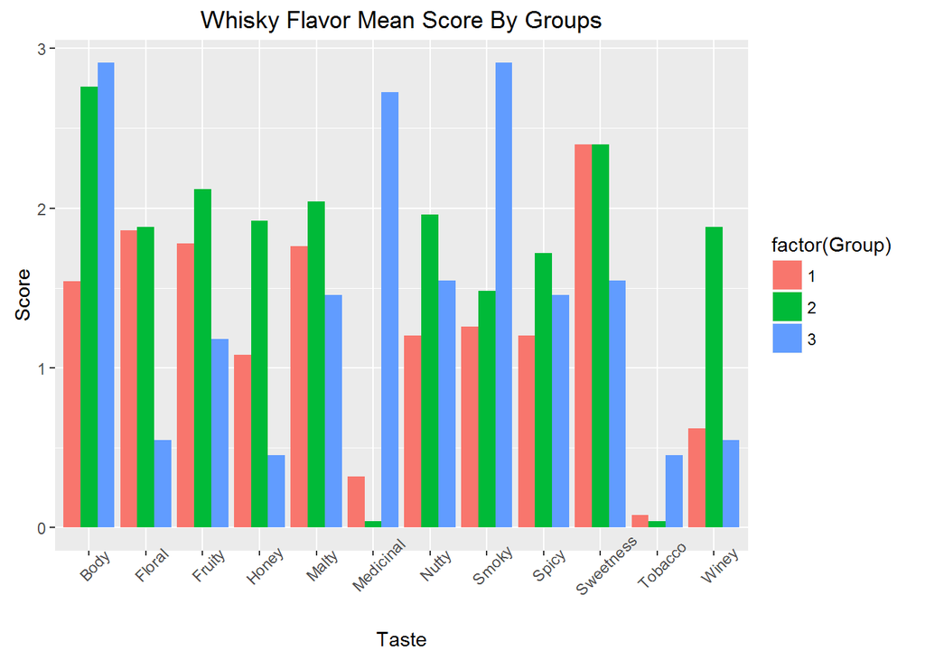

```r
# best clusters
set.seed(777)
best.cluster <- NbClust(whisky.all[,3:14], method = "kmeans")
# add Groups
Groups <- best.cluster$Best.partition
attributes(Groups) <- NULL
table(Groups)
whisky.all$Groups <- as.factor(Groups)
# groups' mean
groups.mean <- aggregate(whisky.all[,3:14], list(whisky.all$Groups), mean)
groups.mean <- gather(groups.mean,"Taste","Score",2:13)
colnames(groups.mean) <- c("Group", "Taste", "Score")
```

接下來，利用每一筆資料所屬的群集及 Distillery 經緯度繪出分佈地圖。使用 ggplot2 及 ggmap 套件，先定位地圖中心、擷取 Google Map 地圖並依經緯度與所屬群集顏色標示，zoom 值手動設定6 (亦可透過 RgoogleMaps 套件的 MaxZoom 自動取得)，從地圖中可觀察出群集3的 Distillery 似乎有分佈在島嶼沿海的特性…

[figure not shown]

```r
# whisky center
w.center <- with(whisky.all, c(mean(Longitude), mean(Latitude)))
# plot Scotch
qmap(location = w.center, zoom = 6, darken = .6) +
  geom_point(data = whisky.all, aes(x = Longitude, y = Latitude, colour = Groups)) +
  theme_classic()
```

為了進一步檢視群集3，這次將地圖定位艾雷島(Islay)，之所以定位於此主要是因為艾雷威士忌以泥煤(peaty)調性聞名，看看群集3所屬的 Distillery 是否能正確反應出這種特性。結果沒讓人失望，Ardbeg, Caol Ila, Lagavulin, Laphroig 等相較於島上其他蒸餾廠，的確充滿強烈酒體、濃濃煙燻藥水等特性

[figure not shown]

```r
# plot Islay
qmap(location = "Islay", zoom = 10, darken = .6) + geom_point() +
  geom_text(data = whisky.all, aes(x = Longitude, y = Latitude, colour = Groups, label = Distillery)
    , fontface = "bold", show.legend = F) +
  theme_classic()
```

最後，列出群集3的資料供參考，看看這些蒸餾廠的威士忌是否都具 peaty 調性? 看來結果大部份是如此~

如果要簡短的描述這3個群集，群集1著重於花果香、低酒體的調性讓人聯想 Speyside 及 Lowlands 區的酒，群集2的特性則有 Highlands 區的影子，豐富又飽滿，群集3則直接讓人聯想到 Islay 及 Islands 區的威士忌，那種特有的泥煤味真是印象深刻.

|  | RowID | Distillery | Body | Sweetness | Smoky | Medicinal | Tobacco | Honey | Spicy | Winey | Nutty | Malty | Fruity | Floral | Postcode | Latitude | Longitude | Groups |
| --- | --- | --- | --- | --- | --- | --- | --- | --- | --- | --- | --- | --- | --- | --- | --- | --- | --- | --- |
| 4 | 4 | Ardbeg | 4 | 1 | 4 | 4 | 0 | 0 | 2 | 0 | 1 | 2 | 1 | 0 | PA427EB | 55.64018 | -6.109065 | 3 |
| 22 | 22 | Caol Ila | 3 | 1 | 4 | 2 | 1 | 0 | 2 | 0 | 2 | 1 | 1 | 1 | PA467RL | 55.85472 | -6.109592 | 3 |
| 24 | 24 | Clynelish | 3 | 2 | 3 | 3 | 1 | 0 | 2 | 0 | 1 | 1 | 2 | 0 | KW96LB | 58.02458 | -3.868194 | 3 |
| 40 | 40 | GlenScotia | 2 | 2 | 2 | 2 | 0 | 1 | 0 | 1 | 2 | 2 | 1 | 1 | PA286DS | 55.42968 | -5.603957 | 3 |
| 56 | 56 | Isle of Jura | 2 | 1 | 2 | 2 | 0 | 1 | 1 | 0 | 2 | 1 | 1 | 1 | PA607XT | 55.83290 | -5.951698 | 3 |
| 58 | 58 | Lagavulin | 4 | 1 | 4 | 4 | 1 | 0 | 1 | 2 | 1 | 1 | 1 | 0 | PA427DZ | 55.63551 | -6.126160 | 3 |
| 59 | 59 | Laphroig | 4 | 2 | 4 | 4 | 1 | 0 | 0 | 1 | 1 | 1 | 0 | 0 | PA427DU | 55.62982 | -6.153523 | 3 |
| 67 | 67 | Oban | 2 | 2 | 2 | 2 | 0 | 0 | 2 | 0 | 2 | 2 | 2 | 0 | PA345NH | 56.41513 | -5.472043 | 3 |
| 69 | 69 | OldPulteney | 2 | 1 | 2 | 2 | 1 | 0 | 1 | 1 | 2 | 2 | 2 | 2 | KW15BA | 58.43472 | -3.085537 | 3 |
| 75 | 75 | Springbank | 2 | 2 | 2 | 2 | 0 | 2 | 2 | 1 | 2 | 1 | 0 | 1 | PA286EJ | 55.42873 | -5.601451 | 3 |
| 78 | 78 | Talisker | 4 | 2 | 3 | 3 | 0 | 1 | 3 | 0 | 1 | 2 | 2 | 0 | IV478SR | 57.30094 | -6.352404 | 3 |

### Lessons Learned: